# Part 2: Vegetation Indices

Patrick Schratz

Sat 06 Jul 2019

# Loading required packages

```r
library("raster")
library("hsdar")
library("here")
library("rasterVis", )
library("mapview")
library("magrittr")
library("stars")
```

# NDVI calculation

## Option 1

We can directly call `hsdar::vegindex()` on our `speclib` object to calculate a vegetation index, for example the “Normalized Difference Vegetation Index” (NDVI).

```r
time <- Sys.time()
ndvi_speclib <- vegindex(speclib, index = "NDVI2")
```

[output not shown]

```r
Sys.time() - time
```

```
Time difference of 0.9450843 secs
```

The resulting `speclib` file contains the new raster NDVI file (`ndvi_speclib@spectra@spectra_ra`). It can be visualized by using the raster slot of the `speclib` object.

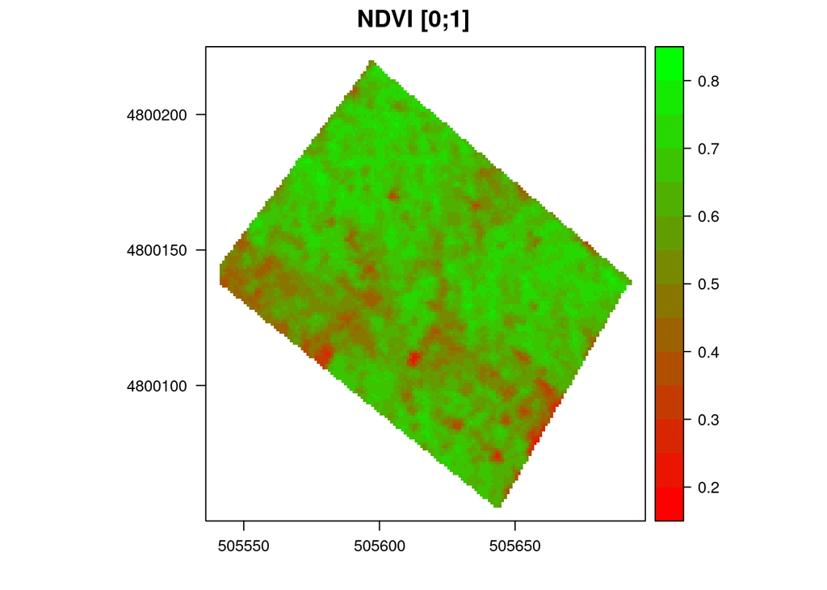

```r
levelplot(ndvi_speclib@spectra@spectra_ra,
  margin = FALSE,
  pretty = TRUE, col.regions = rev(colorRamps::green2red(400)),
  main = "NDVI [0;1]"
)
```

The same logic applies if we want to write the calculated index to disk.

```r
writeRaster(ndvi_speclib@spectra@spectra_ra,
  paste0(here("data/"), "/ndvi.tif"),
  overwrite = TRUE
)
```

## Option 2

It is also possible to use an object of class `HyperSpecRaster` in combination with the *raster* package to calculate vegetation indices. During the function call our object gets automatically converted to class `speclib` and will be transformed back after success.

This approach is not supported by the *hsdar* package. I wrote a wrapper function called `hsdar.vegIndex()` which is avaible on Github. You can install it via `remotes::install_github("pat-s/rasterFunctions")`.

*What does it do?*

This function is an approach for large raster file processing using the *raster* package (`vignette("functions", package = "raster")`) and `hsdar::vegindex()` as the workhorse function.

*Why is this needed?*

Because R processes everything in memory by default, you get in trouble quite early when dealing with large raster files. The image here has 28350 spectra/pixels (162 columns, 175 rows) and takes just a few seconds. However in practice you might find yourself in situations with much larger raster files which might exceed your memory.

One solution for this problem is to do the processing in chunks/blocks and interactively write the calculated values to disk.

(If you want to adapt it this function and use another workhorse function than `hsdar::vegindex()`, just replace the `v <- as.matrix(vegindex(v, index = veg.index))` line with the desired processing function.)

```r
time <- Sys.time()
ndvi_hyperspecraster <- rasterFunctions::hsdar.vegIndex(hyperspecs,
  veg.index = "NDVI2", nl = 1, paste0(here("data/"), "/ndvi.tif")
)
Sys.time() - time
```

```
Time difference of 1.345195 secs
```

For convenience you should use the `speclib` approach and only use the `HyperSpecRaster` approach when you work with large raster files.

Here, we used the formula `NDVI2`. Check `?vegindex` to see all available indices.

# Normalized ratio indices

Also called ‘Narrow band indices’ or ‘Normalized Ratio Indices’ (NRI) are NDVI-like ratios with custom bands:

$$nri_{B1,B2}=\frac{R_{B1}-R_{B2}}{R_{B1}+R_{B2}}$$
There are two possibilities on how to work with NRIs. Either you assign two bands by wavelength from which the NRI should be calculated or you assign `recursive=TRUE` which means that NRIs will be calculated for all possible band combinations.

If there is some time at the end, you can experiment with NRI calculation at the end of the session with the help of the `hsdar` vignette (`vignette("hsdar-intro")`).